# Wisconsin Breast Cancer Prediction

Breast cancer is one the most common types of cancer and most importantly, the deadliest cancer for women. In this project, I will be building 6 Machine Learning algorithms using R-Studio to predict two classes of tumors: benign and malignant.

## Loading data

```r
breastcancer<- read.csv("/Users/zahiernasrudin/Downloads/data 2.csv", header = T, stringsAsFactors = FALSE)
```

## Structure of dataset

```r
str(breastcancer)
```

```
'data.frame':   569 obs. of  33 variables:
 $ id                     : int  842302 842517 84300903 84348301 84358402 843786 844359 84458202 844981 84501001 ...
 $ diagnosis              : chr  "M" "M" "M" "M" ...
 $ radius_mean            : num  18 20.6 19.7 11.4 20.3 ...
 $ texture_mean           : num  10.4 17.8 21.2 20.4 14.3 ...
 $ perimeter_mean         : num  122.8 132.9 130 77.6 135.1 ...
 $ area_mean              : num  1001 1326 1203 386 1297 ...
 $ smoothness_mean        : num  0.1184 0.0847 0.1096 0.1425 0.1003 ...
 $ compactness_mean       : num  0.2776 0.0786 0.1599 0.2839 0.1328 ...
 $ concavity_mean         : num  0.3001 0.0869 0.1974 0.2414 0.198 ...
 $ concave.points_mean    : num  0.1471 0.0702 0.1279 0.1052 0.1043 ...
 $ symmetry_mean          : num  0.242 0.181 0.207 0.26 0.181 ...
 $ fractal_dimension_mean : num  0.0787 0.0567 0.06 0.0974 0.0588 ...
 $ radius_se              : num  1.095 0.543 0.746 0.496 0.757 ...
 $ texture_se             : num  0.905 0.734 0.787 1.156 0.781 ...
```

[output cut: 19 more lines]

## Frequency of tumor

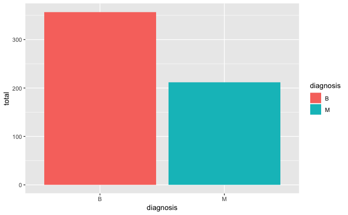

```r
breastcancer %>%
  select(diagnosis)%>%
  group_by(diagnosis)%>%
  summarise(total=n())%>%
  ggplot(aes(x=diagnosis,y=total, fill=diagnosis))+
  geom_bar(stat = "identity")
```

## Missing Value

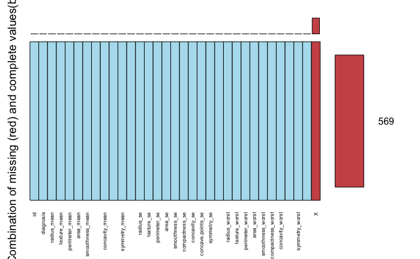

```r
miss<- aggr(breastcancer, col=c('lightblue2','indianred3'),
            numbers=TRUE,prop = F,labels=names(breastcancer), cex.axis=0.55, combined = TRUE,
            ylab= "Combination of missing (red) and complete values(blue)",
            gap=2)
```

```r
#remove a column contains all missing values
breastcancer <- breastcancer[,-33]
```

As you can see from the figure above that the missing values are all in the last column called ???X???. We will remove the column since it is completely useless to have it.

## Histogram

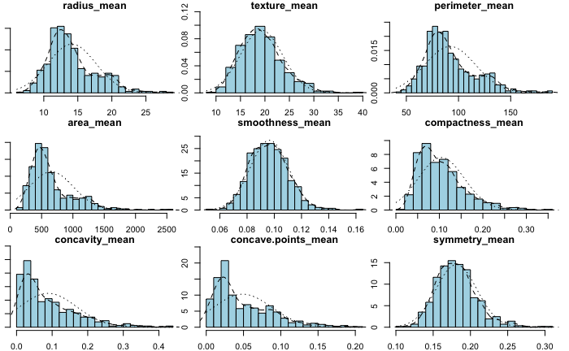

```r
multi.hist(breastcancer[,sapply(breastcancer, is.numeric)][2:10], bcol = 'lightblue')
```

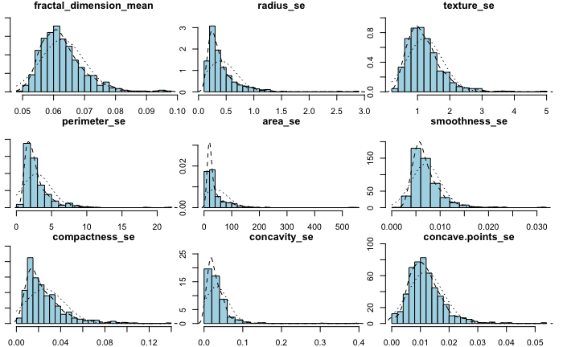

```r
multi.hist(breastcancer[,sapply(breastcancer, is.numeric)][11:19], bcol = 'lightblue')
```

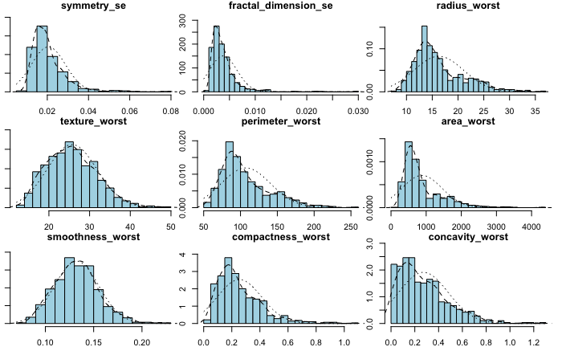

```r
multi.hist(breastcancer[,sapply(breastcancer, is.numeric)][20:28], bcol = 'lightblue')
```

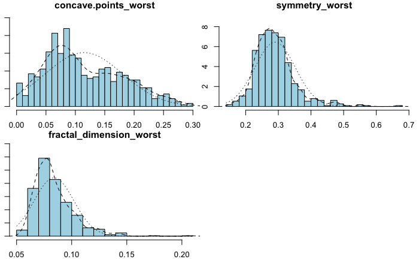

```r
multi.hist(breastcancer[,sapply(breastcancer, is.numeric)][29:31], bcol = 'lightblue')
```

## Skewness

```r
continuous_variables<- breastcancer[,sapply(breastcancer, is.numeric)]
colSkewness(continuous_variables[-1])
```

```
            radius_mean            texture_mean          perimeter_mean               area_mean
              0.9374168               0.6470241               0.9854334               1.6370654
        smoothness_mean        compactness_mean          concavity_mean     concave.points_mean
              0.4539207               1.1838556               1.3938008               1.1650124
          symmetry_mean  fractal_dimension_mean               radius_se              texture_se
              0.7217877               1.2976191               3.0723468               1.6377733
           perimeter_se                 area_se           smoothness_se          compactness_se
              3.4254803               5.4185001               2.3022616               1.8922032
           concavity_se       concave.points_se             symmetry_se    fractal_dimension_se
              5.0835502               1.4370701               2.1835728               3.9033041
           radius_worst           texture_worst         perimeter_worst              area_worst
              1.0973059               0.4956970               1.1222227               1.8495814
       smoothness_worst       compactness_worst         concavity_worst    concave.points_worst
              0.4132383               1.4657948               1.1441794               0.4900213
         symmetry_worst fractal_dimension_worst
              1.4263764               1.6538237
```

As you can see from the histograms and the skewness values, it can be seen that most the variables are either normally distributed or skewed to the right.

## Transform certain attributes that are skewed to the right

```r
#cube root transformation
normal_cube<-sign(continuous_variables[,c(4,11,
                                          12,13,14,
                                          15,16,17,18,19,
                                          20,21,25,31)]) * abs(continuous_variables[,c(4,11,
                                                                                       12,13,14,
                                                                                       15,16,17,18,19,
                                                                                       20,21,25,31)])^(1/3)
breastcancer_new<-cbind(continuous_variables[,c(1,2,3,5,
                                                6,7,8,9,10,
                                                22,23,24,
                                                26,27,28,29,30)],
                        normal_cube,breastcancer[,sapply(breastcancer,is.character)])
colnames(breastcancer_new)[32]<- "diagnosis"
```

## Split dataset to 70:30

```r
set.seed(23564)
portion= createDataPartition(breastcancer_new$diagnosis, p=0.7, list = FALSE)
train= breastcancer_new[portion,]
test= breastcancer_new[-portion,]
table(train$diagnosis)
```

```
  B   M
250 149
```

```r
table(test$diagnosis)
```

```
  B   M
107  63
```

```r
#cross validation
set.seed(236)
cvfolds= createMultiFolds(train$diagnosis,k=10)
cv.ctrl=trainControl(method = "repeatedcv",number = 10, repeats = 3,
                     index = cvfolds)
```

## Implement Machine Learning Algorithm

6 Machine Learning algorithms will be built: Logistic Regression, Naive Bayes, Decision Tree, Neural Network, Random Forest, Support Vector Machines (SVMs). For SVMs, linear and two non-linear kernels (Poly and RBF) will be executed

```r
#rpart

rpart.cv = train(diagnosis~., data= train[,-1], method="rpart",
                 trControl=cv.ctrl, tuneLength=7)

test_pred=predict(rpart.cv,newdata = test[,-1])
cm_rpart= confusionMatrix(test_pred, test$diagnosis)

#logistic

logistic.cv = train(diagnosis~., data= train[,-1], method="glm",
                 trControl=cv.ctrl, tuneLength=7)
test_pred_logistic=predict(logistic.cv, newdata= test[,-1])
cm_logistic= confusionMatrix(test_pred_logistic,test$diagnosis)

#naive bayes

naive_bayes.cv = train(diagnosis ~., data = train[,-1], method = "nb",
                    trControl=cv.ctrl,
                    tuneLength = 7)
test_pred_naivebayes=predict(naive_bayes.cv, newdata= test[,-1])
cm_naivebayes=confusionMatrix(test_pred_naivebayes,test$diagnosis)

#svmradial
svm_radial.cv <- train(diagnosis ~., data = train[,-1], method = "svmRadial",
             trControl=cv.ctrl,
             tuneLength = 7)
test_pred_radial<- predict(svm_radial.cv, newdata= test[,-1])
cm_svmradial=confusionMatrix(test_pred_radial,test$diagnosis)



#svmpoly
svm_poly.cv <- train(diagnosis ~., data = train[,-1], method = "svmPoly",
                   trControl=cv.ctrl,
                   tuneLength = 7)
test_pred_poly<- predict(svm_poly.cv, newdata= test[,-1])
cm_svmpoly=confusionMatrix(test_pred_poly,test$diagnosis)

#svmlinear

svmlinear.cv <- train(diagnosis ~., data = train[,-1], method = "svmLinear",
                   trControl=cv.ctrl,
                   tuneLength = 7)
test_pred_svmlinear<- predict(svmlinear.cv, newdata= test[,-1])
cm_svmlinear=confusionMatrix(test_pred_svmlinear,test$diagnosis)

#neuralnetwork

neural.cv <- train(diagnosis ~., data = train[,-1], method = "nnet",
                      trControl=cv.ctrl,
                      tuneLength = 7)
test_pred_neural<- predict(neural.cv, newdata= test[,-1])
cm_neural=confusionMatrix(test_pred_neural,test$diagnosis)



#random forest
library(party)
randomforest.cv <- train(diagnosis ~., data = train[,-1], method = "cforest",
                      trControl=cv.ctrl,
                      tuneLength = 7)
test_pred_randomforest<- predict(randomforest.cv, newdata= test[,-1])
cm_randomforest=confusionMatrix(test_pred_randomforest,test$diagnosis)
```

## Confusion Matrix

```r
#decision tree
cm_rpart
```

```
Confusion Matrix and Statistics

          Reference
Prediction  B  M
         B 97  2
         M 10 61

               Accuracy : 0.9294
                 95% CI : (0.8799, 0.963)
    No Information Rate : 0.6294
    P-Value [Acc > NIR] : < 2e-16

                  Kappa : 0.8525
 Mcnemar's Test P-Value : 0.04331

            Sensitivity : 0.9065
            Specificity : 0.9683
         Pos Pred Value : 0.9798
         Neg Pred Value : 0.8592
             Prevalence : 0.6294
         Detection Rate : 0.5706
   Detection Prevalence : 0.5824
      Balanced Accuracy : 0.9374

       'Positive' Class : B
```

```r
#Logistic Regression
cm_logistic
```

```
Confusion Matrix and Statistics

          Reference
Prediction   B   M
         B 102   3
         M   5  60

               Accuracy : 0.9529
                 95% CI : (0.9094, 0.9795)
    No Information Rate : 0.6294
    P-Value [Acc > NIR] : <2e-16

                  Kappa : 0.8998
 Mcnemar's Test P-Value : 0.7237

            Sensitivity : 0.9533
            Specificity : 0.9524
         Pos Pred Value : 0.9714
         Neg Pred Value : 0.9231
             Prevalence : 0.6294
         Detection Rate : 0.6000
   Detection Prevalence : 0.6176
      Balanced Accuracy : 0.9528

       'Positive' Class : B
```

```r
#Naive Bayes
cm_naivebayes
```

```
Confusion Matrix and Statistics

          Reference
Prediction   B   M
         B 100   3
         M   7  60

               Accuracy : 0.9412
                 95% CI : (0.8945, 0.9714)
    No Information Rate : 0.6294
    P-Value [Acc > NIR] : <2e-16

                  Kappa : 0.8755
 Mcnemar's Test P-Value : 0.3428

            Sensitivity : 0.9346
            Specificity : 0.9524
         Pos Pred Value : 0.9709
         Neg Pred Value : 0.8955
             Prevalence : 0.6294
         Detection Rate : 0.5882
   Detection Prevalence : 0.6059
      Balanced Accuracy : 0.9435

       'Positive' Class : B
```

```r
#Support Vector Machines RBF
cm_svmradial
```

```
Confusion Matrix and Statistics

          Reference
Prediction   B   M
         B 104   1
         M   3  62

               Accuracy : 0.9765
                 95% CI : (0.9409, 0.9936)
    No Information Rate : 0.6294
    P-Value [Acc > NIR] : <2e-16

                  Kappa : 0.9499
 Mcnemar's Test P-Value : 0.6171

            Sensitivity : 0.9720
            Specificity : 0.9841
         Pos Pred Value : 0.9905
         Neg Pred Value : 0.9538
             Prevalence : 0.6294
         Detection Rate : 0.6118
   Detection Prevalence : 0.6176
      Balanced Accuracy : 0.9780

       'Positive' Class : B
```

```r
#Support Vector Machines Polynomial
cm_svmpoly
```

```
Confusion Matrix and Statistics

          Reference
Prediction   B   M
         B 106   0
         M   1  63

               Accuracy : 0.9941
                 95% CI : (0.9677, 0.9999)
    No Information Rate : 0.6294
    P-Value [Acc > NIR] : <2e-16

                  Kappa : 0.9874
 Mcnemar's Test P-Value : 1

            Sensitivity : 0.9907
            Specificity : 1.0000
         Pos Pred Value : 1.0000
         Neg Pred Value : 0.9844
             Prevalence : 0.6294
         Detection Rate : 0.6235
   Detection Prevalence : 0.6235
      Balanced Accuracy : 0.9953

       'Positive' Class : B
```

```r
#Support Vector Machines Linear
cm_svmlinear
```

```
Confusion Matrix and Statistics

          Reference
Prediction   B   M
         B 103   0
         M   4  63

               Accuracy : 0.9765
                 95% CI : (0.9409, 0.9936)
    No Information Rate : 0.6294
    P-Value [Acc > NIR] : <2e-16

                  Kappa : 0.9502
 Mcnemar's Test P-Value : 0.1336

            Sensitivity : 0.9626
            Specificity : 1.0000
         Pos Pred Value : 1.0000
         Neg Pred Value : 0.9403
             Prevalence : 0.6294
         Detection Rate : 0.6059
   Detection Prevalence : 0.6059
      Balanced Accuracy : 0.9813

       'Positive' Class : B
```

```r
#Neural Network
cm_neural
```

```
Confusion Matrix and Statistics

          Reference
Prediction   B   M
         B 101   0
         M   6  63

               Accuracy : 0.9647
                 95% CI : (0.9248, 0.9869)
    No Information Rate : 0.6294
    P-Value [Acc > NIR] : < 2e-16

                  Kappa : 0.9258
 Mcnemar's Test P-Value : 0.04123

            Sensitivity : 0.9439
            Specificity : 1.0000
         Pos Pred Value : 1.0000
         Neg Pred Value : 0.9130
             Prevalence : 0.6294
         Detection Rate : 0.5941
   Detection Prevalence : 0.5941
      Balanced Accuracy : 0.9720

       'Positive' Class : B
```

```r
#Random Forest
cm_randomforest
```

```
Confusion Matrix and Statistics

          Reference
Prediction   B   M
         B 102   2
         M   5  61

               Accuracy : 0.9588
                 95% CI : (0.917, 0.9833)
    No Information Rate : 0.6294
    P-Value [Acc > NIR] : <2e-16

                  Kappa : 0.9126
 Mcnemar's Test P-Value : 0.4497

            Sensitivity : 0.9533
            Specificity : 0.9683
         Pos Pred Value : 0.9808
         Neg Pred Value : 0.9242
             Prevalence : 0.6294
         Detection Rate : 0.6000
   Detection Prevalence : 0.6118
      Balanced Accuracy : 0.9608

       'Positive' Class : B
```

## Plot Accuracy

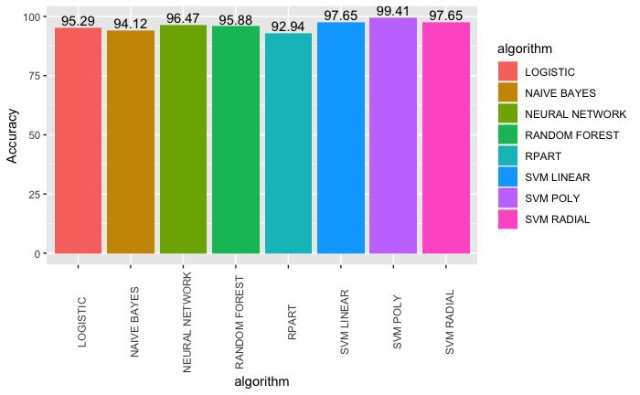

```r
accuracy= data.frame(algorithm= c("RPART","LOGISTIC","NAIVE BAYES","SVM RADIAL",
                                  "SVM POLY", "SVM LINEAR","NEURAL NETWORK", "RANDOM FOREST"),
                     score= round(c(cm_rpart$overall[1]*100,cm_logistic$overall[1]*100
                              ,cm_naivebayes$overall[1]*100,cm_svmradial$overall[1]*100,
                              cm_svmpoly$overall[1]*100,cm_svmlinear$overall[1]*100,
                              cm_neural$overall[1]*100, cm_randomforest$overall[1]*100),2))
ggplot(data=accuracy, aes(x=algorithm, y=score, fill=algorithm)) +
  geom_bar(stat="identity")+
  labs(y="Accuracy")+
  theme(axis.text.x = element_text(angle = 90))+
  geom_text(aes(label=score), position=position_dodge(width=0.9), vjust=-0.25)
```

As you can see from the figure above that the SVM Poly has the best accuracy value (99.41%). In future work, PCA could be done to select variables without removing important variables. Thank you